# Parameterizing the Genetic Architecture Under Stabilizing Selection

Hanbin Lee

hblee@umich.edu

University of Michigan, Ann Arbor

March 27, 2026

# Motivation

- In quantitative genetics, a (empirical) Bayesian linear model is used.
  $$y = \sum_j G_j \beta_j + \varepsilon$$
- How do we determine the prior on $\beta$?
- Across many complex traits, variants with larger effects tend to be rarer.<sup>1</sup>

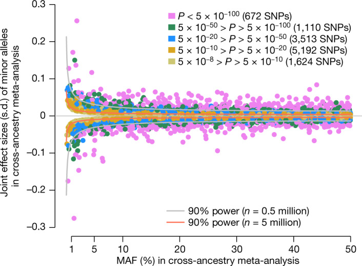

- A standard statistical description is the $\alpha$-model:
  $$\mathrm{Var}(\beta_j \mid p_j) \propto [p_j(1-p_j)]^{-\alpha}$$
- The phenomenon is attributed to negative selection
- Variants with larger effect are removed by selection
- Many proposals, all are merely *curve fitting*
[^1]: Figure adapted from Yengo et al. (2022).

## Main idea

- We derive $\beta_j$’s from evolutionary theory.
- Start from stabilizing selection under Fisher’s geometric model (FGM) (Fisher 1930; Tenaillon 2014):
  $$\text{fitness} \propto \exp\left(-\frac{\|z\|^2}{2V_S}\right)$$
- Introduce a focal trait $y$ that is coupled to an unobserved selected trait $z$.
- Derive the induced frequency dependence of $\beta_j$.

# Evolutionary setup

## Stabilizing selection

- Fitness is modeled as
  $$\text{fitness} \propto \exp\left(-\frac{\|z\|^2}{2V_S}\right)$$
- For locus $j$ with effect vector $\alpha_j$, the marginal selection coefficient is
  $$s_{\mathrm{eff}}(x_j) = \left(x_j - \frac{1}{2}\right)\frac{\|\alpha_j\|^2}{V_S}$$
- This yields a stationary allele-frequency density that depends on $\|\alpha_j\|^2/W_S$.

## From fitness effects to focal-trait effects

- We model the focal-trait variance conditional on the fitness effect by
  $$\mathbb{E}[\beta_j^2 \mid \|\alpha_j\|]
  =
  \sigma_b^2 (1-\rho_{ab}^2)
  + \rho_{ab}^2 \frac{\sigma_b^2}{\sigma_a^2}\|\alpha_j\|^2$$
- Here:
  - $\sigma_a^2$ controls mutational variance for the selected trait,
  - $\sigma_b^2$ controls the overall variance scale of the focal trait,
  - $\rho_{ab}^2$ controls coupling between the focal trait and selection.

# Approximate genetic architecture

## Key derivation

- Using Bayes’ rule together with the stationary allele-frequency model,
  $$p(\|\alpha_j\|^2 \mid G_j)
  \propto
  p(G_j \mid \|\alpha_j\|^2)p(\|\alpha_j\|^2)$$
- Under the low-mutation approximation,
  $$\mathbb{E}[\|\alpha_j\|^2 \mid G_j]
  =
  \frac{\sigma_a^2}{
  1 + 2\frac{\sigma_a^2}{W_S}\hat p_j(1-\hat p_j)}$$
- Substituting this into the pleiotropy model gives
  $$\mathbb{E}[\beta_j^2 \mid G_j]
  =
  \sigma_b^2
  \left(
  1
  -
  \rho_{ab}^2
  \frac{2\frac{\sigma_a^2}{W_S}\hat p_j(1-\hat p_j)}
  {1 + 2\frac{\sigma_a^2}{W_S}\hat p_j(1-\hat p_j)}
  \right)$$

## Interpretation

- The model is frequency-dependent, but unlike the $\alpha$-model it does not diverge as $\hat p_j \to 0$.
- The parameters have direct evolutionary interpretations.
- In practice, the most identifiable selection-sensitive quantity is the product
  $$\rho_{ab}^2 \sigma_a^2 / W_S$$

# Simulation design

## How these models are usually evaluated

- Most benchmarking studies condition on a fixed genotype matrix rather than simulating evolution explicitly.

  $$y = G\beta + \varepsilon$$
- They then generate phenotypes by varying only:
  - the random effect sizes under a chosen prior of $\beta$
  - the residual noise $\varepsilon$
- You simulate from your model so can never be wrong.

## Forward simulations in SLiM

- Individual-based forward simulations under stabilizing selection.
- Constant diploid population size $N=10{,}000$.
- Genome length $L = 2 \times 10^6$, mutation rate $\mu = 10^{-8}$, recombination rate $r = 10^{-5}$.
- Grid over:
  - $\sigma_a^2 \in \{0.5, 1.0, 2.0\}$,
  - $W_S \in \{1.0, 2.0, 4.0\}$,
  - $\rho_{ab}^2 \in \{0, 0.5, 1\}$.
- We evaluate both variance-component recovery and held-out BLUP prediction.

# Results

## Recovering the selection-sensitive component

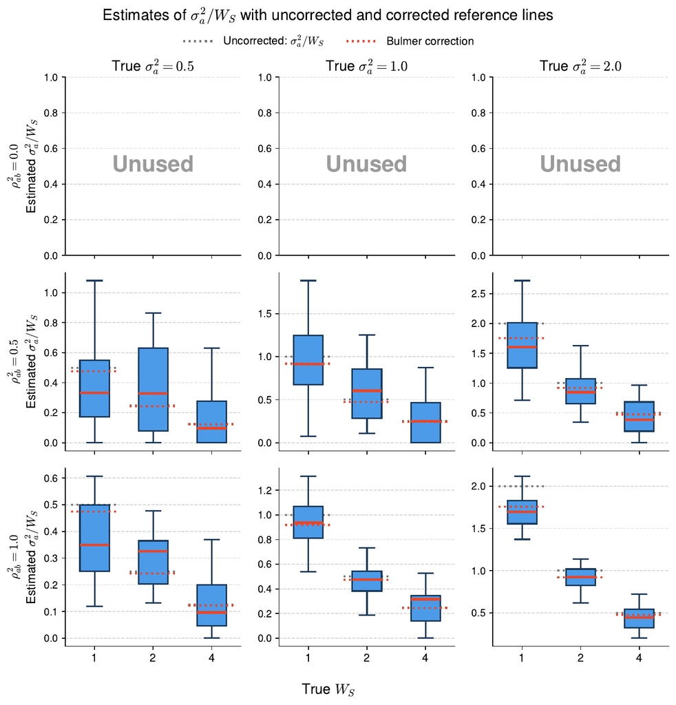

## Recovering the overall variance scale

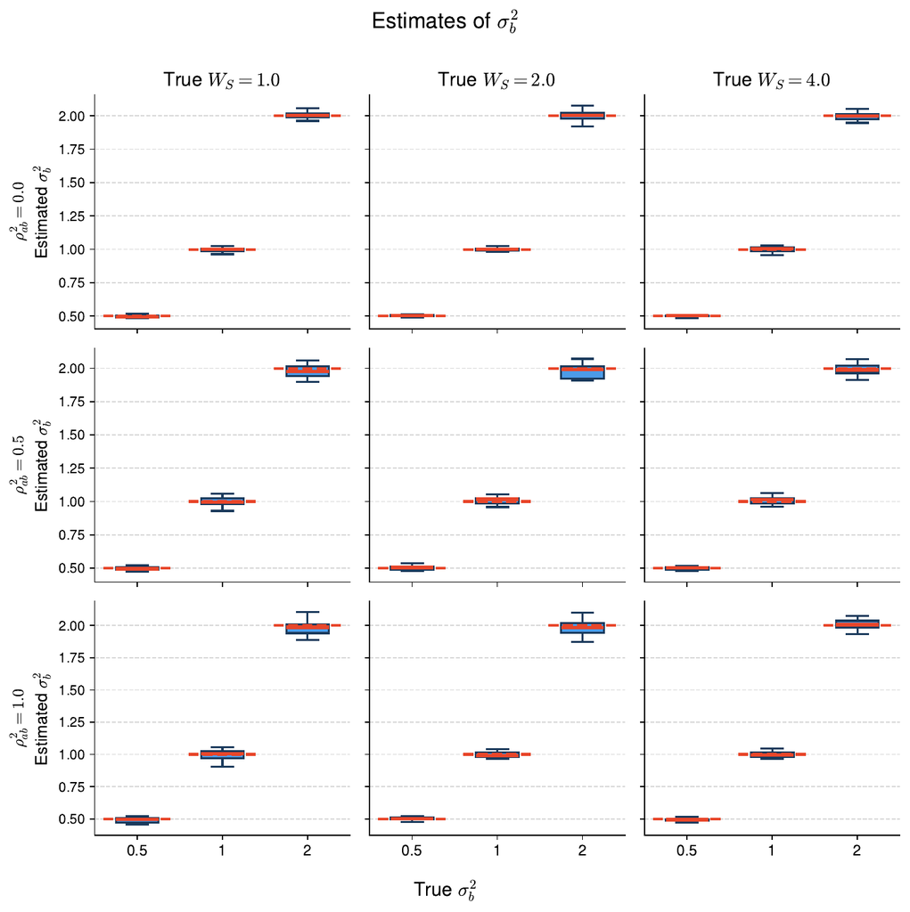

- $\sigma_b^2$ is much easier to estimate than $\sigma_a^2/W_S$.
- REML estimates of $\sigma_b^2$ remain centered near the true value across the full simulation grid.
- The focal-trait variance is well identified, while the selection-sensitive component is more sensitive to departures from the single-locus approximation.

## Prediction accuracy

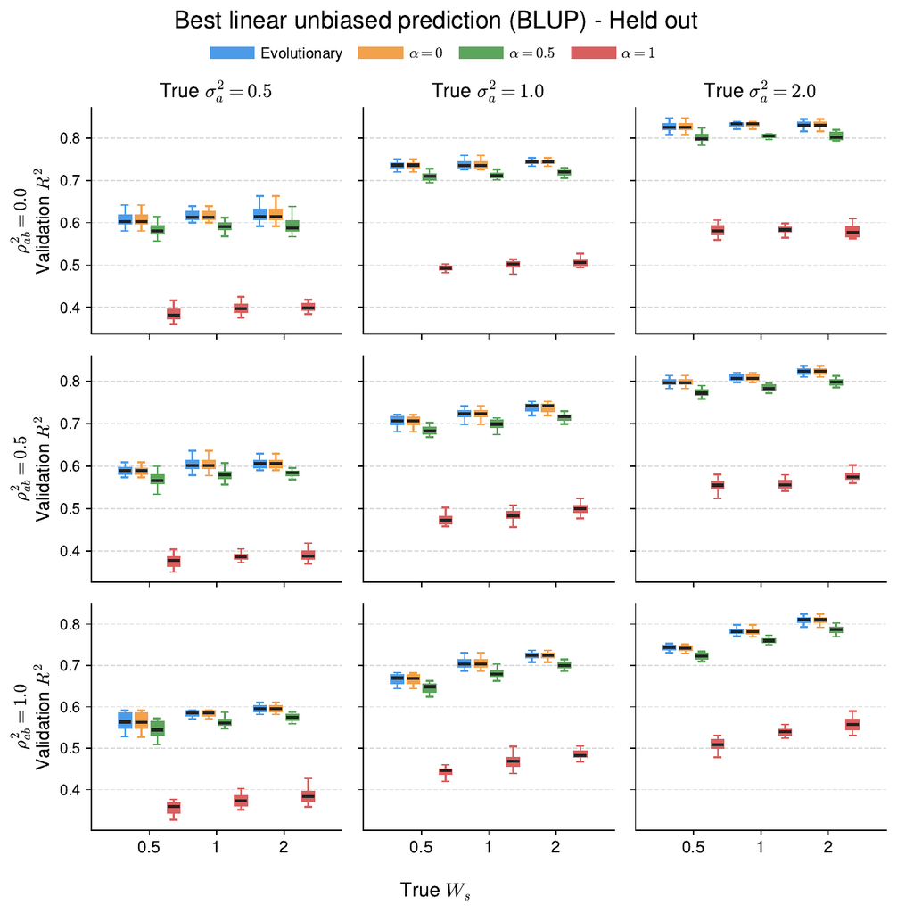

- The evolutionary model performs best overall.
- $\alpha=1$ performs worst throughout the grid.
- $\alpha=0.5$ is closer, but still remains below the evolutionary fit through most of the grid; $\alpha=0$ is often close, especially when $\rho_{ab}^2=0$.
- Similar BLUP accuracy does not imply recovery of the same architecture.

## Variance components

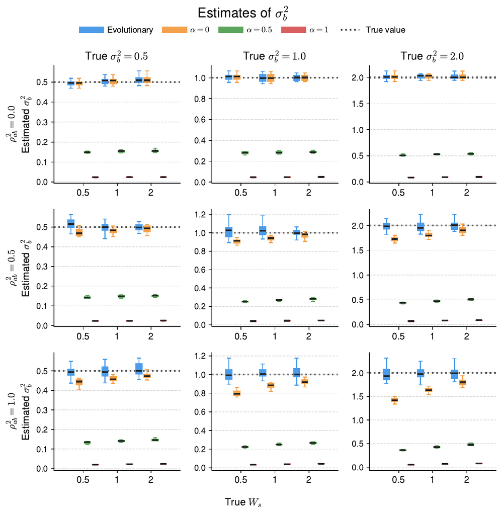

- The evolutionary model remains close to the true $\sigma_b^2$.
- The $\alpha=0$ model is approximately unbiased only when $\rho_{ab}^2=0$ and becomes downward biased once the focal trait inherits frequency dependence.
- The $\alpha=0.5$ and $\alpha=1$ fits underestimate $\sigma_b^2$ much more severely, showing that the $\alpha$-model misses the frequency-dependent architecture.

## Summary

- We derive a frequency-dependent mixed model for effect sizes from stabilizing selection rather than imposing it heuristically.
- The framework connects fitness-landscape theory to REML estimation and BLUP prediction.
- We can do statistical genetics like physics instead of random curve fitting.
- In simulations, the model recovers the focal-trait variance well and generally outperforms conventional $\alpha$-model baselines in prediction.
- Extending the framework to richer pleiotropy models and explicit linkage disequilibrium is a natural next step.

## References

Fisher, Ronald Aylmer. 1930. *The Genetical Theory of Natural Selection*. Oxford University Press. https://openlibrary.org/books/OL6898400M/The_genetical_theory_of_natural_selection.

Tenaillon, O. 2014. “The Utility of Fisher’s Geometric Model in Evolutionary Genetics.” *Annual Review of Ecology, Evolution, and Systematics* 45 (1): 179–201. https://doi.org/10.1146/annurev-ecolsys-120213-091846.

Yengo, Loïc, Sailaja Vedantam, Eirini Marouli, Julia Sidorenko, Eric Bartell, Saori Sakaue, Marielisa Graff, et al. 2022. “A Saturated Map of Common Genetic Variants Associated with Human Height.” *Nature* 610 (7933): 704–12. https://doi.org/10.1038/s41586-022-05275-y.